# Review and Basics of R

## Important Definitions

- **Statistics**: the science and art of collecting, analyzing, and drawing conclusions from data.
- **Population of Interest**: Group of individuals we wish to know more information about
- **Sample**: Subset of the population of interest from which we can obtain information
- **Individuals**: the subjects/objects of the population of interest; can be people, but also business firms, common stocks, or any other object we want to study.
- **Variable**: any characteristic of an individual that we can measure and observe.

## Uploading a dataset to R

```r
# This is a very common R package that easily creates tidy data easier for
# analysis and make beautiful graphs!
library(tidyverse)
# R needs to have a specific place specified to look for documents/data sets to upload.
# To tell R to start looking where the qmd file is, use Session > Set Working Directory > To Source File Location
dat <- read.csv("Data/airfares.csv")
```

## Parameters and Statistics

- **Population Parameter**: A numeric value that describes the characteristics of an entire population
- **Sample Statistic**: A numeric value that describes the characteristics of the observed data from a sample

Recall, we use **sample statistics** to make inference about **population parameters**.

Some important sample statistics:

- **Sample Mean**: $\bar{X} = \frac{1}{n}\sum_{i=1}^n X_i$
- **Sample Variance**: $S_x^2 = \frac{1}{n - 1}\sum_{i=1}^n (X_i - \bar{X})^2$
- **Sample Standard Deviation**: $S_x = \sqrt{S_x^2}$

To add another chunk of code, use Ctrl-alt-I for PCs, Cmd-option-I for Macs.

```r
dist <- dat$Distance # this calls the column named Distance in the data frame dat
dat[1:10,] # extract just the first 10 rows, and all columns of the dataset
```

```
   City Fare Distance
1     1  360     1463
2     2  360     1448
3     3  207      681
4     4  111      270
5     5   93      190
6     6  141      393
7     7  291     1102
8     8  183      578
9     9  309     1204
10   10  300     1138
```

```r
# naming convention is dataframe$variablename
# dist is now saved in the environment, so you only need to call the object dist when extracting information about Distance from the data frame
mean(dist)
```

```
[1] 816.5294
```

```r
var(dist)
```

```
[1] 346679
```

```r
sd(dist)
```

```
[1] 588.7945
```

## Random Variables and Distributions

- **Random Variable** denote a variable whose observed values may be considered outcomes of a stochastic or random experiment. Random variables are typically denoted by a capital letter $X$, $Y$, etc., while observations are typically denoted by lowercase letters $x$, $y$, etc.
- Note: When a dollar sign is outside of R code in the main text, this is LaTeX math notation

Recall, a data frame contains **observations** from multiple **random variables** from a particular **sample** from the **population of interest**.

## Normal Distribution

If a random variable $X$ is normally distributed, this is denoted as
$$X \sim \mathcal{N}(\mu_x,\sigma_x^2)$$
where $\mu_x$ is the mean of $X$ and $\sigma_x$ is the standard deviation of $X$.

### Example

Suppose $X \sim \mathcal{N}(2,4)$.

### a

What is $Pr(X > 3.5)$?

```r
# We want to calculate a (p)robability from the (norm)al distribution
# Note, by default, R calculates the probability below the entered value
1 - pnorm(3.5,mean=2,sd=2)
```

```
[1] 0.2266274
```

```r
pnorm(3.5,mean=2,sd=2,lower.tail=FALSE)
```

```
[1] 0.2266274
```

### b

What is the $0.35$ quantile/$35^{th}$ percentile of $X$?

```r
# We want to calculate a (q)uantile from the (norm)al distribution
qnorm(0.35,mean=2,sd=2)
```

```
[1] 1.229359
```

## Central Limit Theorem

Define $\bar{X}$ as the random variable associated with the mean of a sample $\bar{x}$.

If a random variable $X$ is normally distributed with mean $\mu_x$ and standard deviation $\sigma_x$ OR the sample size $n_x$ is sufficiently large ($n_x > 30$), then the **sampling distribution of the sample mean**,
$$\bar{X} \approx \mathcal{N}\left(\mu,\frac{\sigma^2}{n}\right)$$
or, in other words,
$$\frac{\bar{X} - \mu}{\frac{\sigma}{\sqrt{n}}} \approx \mathcal{N}(0,1).$$
This is an important theorem used in estimation and inference, and will be used throughout the semester.

## Chi-squared $\chi^2$ Distribution

Let $S_x^2$ be the random variable associated with the sample variance $s_x^2$. The chi-squared distribution can be used to describe the distribution of $S_x^2$, among other types of random variables. More specifically,
$$\frac{(n-1)S_x^2}{\sigma^2} \sim \chi^2_{df = n-1}.$$

The chi-squared distribution applies only to positive random variables and is significantly skewed to the right.

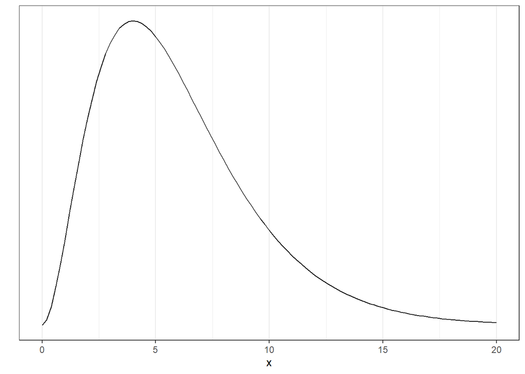

## $t$ Distribution

Let $Z \sim \mathcal{N}(0,1)$ and $X \sim \chi^2_{n-1}$ where $Z$ and $X$ are independent. Then

$$\frac{Z}{\sqrt{X/(n-1)}} \sim t_{df = n-1}$$

Recall that we previously defined $\frac{\bar{X} - \mu}{\frac{\sigma}{\sqrt{n}}} \approx \mathcal{N}(0,1)$ and $\frac{(n-1)S_x^2}{\sigma^2} \sim \chi^2_{df = n-1}.$ It can be proven that these variables are also independent of each other (will cover topics like this in STAT 405). Therefore, putting these two items together, we have
$$\frac{\bar{X} - \mu}{\frac{s_x}{\sqrt{n}}} \sim t_{df = n-1}.$$

Like the normal distribution, the $t$ distribution is also symmetric and unimodal, but has fatter tails to account for the fact that we are using an estimate $s_x$ instead of $\sigma_x$.

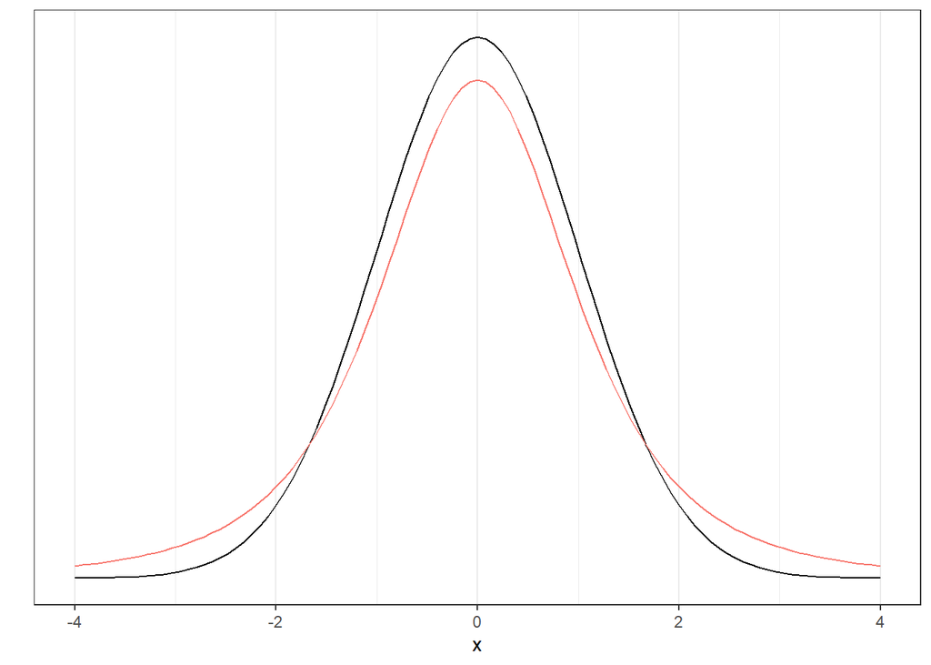

### Example

Suppose $X \sim t_{df=10}$.

### a

What is $Pr(X < 2.2)$?

```r
pt(2.2,df=10)
```

```
[1] 0.9737795
```

### b

What is the $0.8$ quantile/$80^{th}$ percentile of $X$?

```r
qt(0.8,df=10)
```

```
[1] 0.8790578
```

## $F$ Distribution

Suppose now we have $X \sim \chi^2_{df = \nu_1}$ and $Y \sim \chi^2_{df = \nu_2}$ where $X$ and $Y$ are independent. Then,
$$\frac{X/\nu_1}{Y/\nu_2} \sim F_{df1 = \nu_1,df2 = \nu_2}$$
where $df1$ is denoted as the **numerator degrees of freedom** and $df2$ is denoted as the **denominator degrees of freedom**.

For example, if $S_x^2$ and $S_y^2$ are sample variances for independent random variables $X$ and $Y$, respectively, and we assume sample sizes of $n_x$ and $n_y$, we can use the above defintions of chi-squared distributions to show that
$$\frac{S_x^2/\sigma_x^2}{S_y^2/\sigma_y^2} \sim F_{df1 = n_x-1,df2 = n_y - 1}.$$

The $F$ distribution is used to calculate p-values in multiple linear regression hypothesis testing!

Like the $\chi^2$ distribution, the $F$ distribution is skewed to the right.

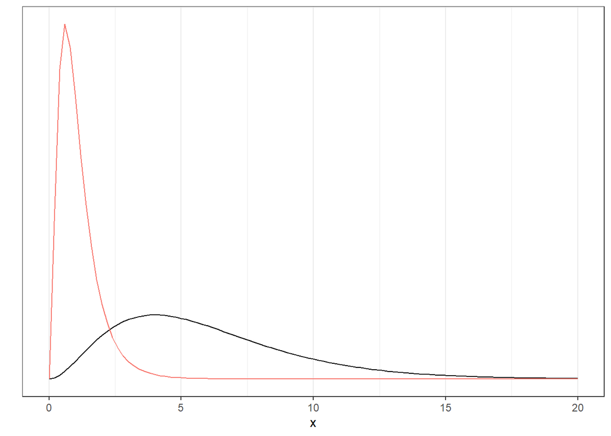

### Example

Suppose $X \sim F_{df1=6,df2=21}$.

### a

What is $Pr(X < 1.3)$?

```r
pf(1.3,6,21)
```

```
[1] 0.6998712
```

### b

Find $x$ such that $Pr(X > x) = 0.4$.

```r
qf(1-0.4,6,21)
```

```
[1] 1.090613
```

```r
qf(0.4,6,21,lower.tail=FALSE)
```

```
[1] 1.090613
```

The $F$ distribution is related to the $t$ distribution because if a random variable $T \sim t_{df=\nu}$, then $T^2 \sim F(df1=1,df2=\nu)$

## Notes for distribution calculations in R

- Starts with p: We are inputting a *quantile* to output a *probability*
- Starts with q: We are inputting a *probability* to output a *quantile*
- norm: We are using a *Normal* distribution with mean $\mu$ and standard deviation $\sigma$
- t: We are using a *t* distribution with degrees of freedom $df$
- f: We are using an *F* distribution with numerator degrees of freedom $df1$ and denominator degrees of freedom $df2$

# Statistical Inference

## Estimation

- **Estimation**: The category of statistical inference concerned with quantifying the specific value of a population parameter.

For example, if we have a random sample of data $x_1,x_2,\dots,x_n$ from a population, we can obtain an estimate of the population mean, $\mu$, by the sample mean $\bar{x}$.

Can we say that $\bar{x}$ is equivalent to $\mu$?

**NO**, different samples produce different sample means.

We need to find a way to quantify the uncertainty of our estimate of the population parameter we are interested in (the population mean in this example).

- **Confidence Interval**: A pair of values that provides a range of *plausible* values for the population parameter for a given level of confidence $C = 100 \times (1 - \alpha)$.
  - $\alpha$ is the given level of significance

### Assumptions needed to calculate a confidence interval

- Data comes from a random sample from the population of interest.

Recall that $\frac{\bar{X} - \mu}{\frac{s_x}{\sqrt{n}}} \sim t_{df = n-1}.$ Define $t_\alpha^*$ as a value from the $t$-distribution such that $P(-t_\alpha^* \leq \frac{\bar{X} - \mu}{s_x/\sqrt{n}} \leq t_\alpha^*) = 1 - \alpha$.

Solving the interior for $\mu$ we get $P(\bar{x} - t_\alpha^*\frac{s_x}{\sqrt{n}} \leq \mu \leq \bar{x} + t_\alpha^*\frac{s_x}{\sqrt{n}}) = 1 - \alpha$.

A $C\%$ confidence interval for a population mean, $\mu$ is written as
$$\bar{x} \pm t_{n-1,1-\frac{\alpha}{2}} \times \frac{s_x}{\sqrt{n}},$$
where $t_{n-1,1-\frac{\alpha}{2}}$ is the $1-\frac{\alpha}{2}$ quantile of the $t$-distribution with $n-1$ degrees of freedom.

### Example

Recall the airfares dataset we previously uploaded into our R session. Assume that the data comes from the population of interest, which in this case is all domestic flights out of O’Hare International Airport. Calculate a 95% confidence interval for the mean flight distance.

```r
# We are going to use the R object dist that we previously defined
xbar <- mean(dist)
s <- sd(dist)
n <- length(dist) # counts the number of elements in the inputted vector
alpha <- 0.05
crit <- qt(1-0.05/2,df=n-1)
# c(-1,1) is a vector of the numbers -1 and 1
# This will represent the plus/minus notation when calculating confidence intervals
xbar + c(-1,1) * crit * s / sqrt(n)
```

```
[1]  513.7992 1119.2596
```

```r
# Short cut using R
t.test(dist,conf.level = 0.95)
```

```
    One Sample t-test

data:  dist
t = 5.7178, df = 16, p-value = 3.174e-05
alternative hypothesis: true mean is not equal to 0
95 percent confidence interval:
  513.7992 1119.2596
sample estimates:
mean of x
 816.5294
```

(513.80, 1119.26) miles

### Interpreting a confidence interval

We **cannot say** there is a 95% probability that the true population parameter is between the values in the confidence interval. Once the interval is calculated, it either **does** contain the true parameter, or it **does not**.

We are $\boldsymbol{C\%}$ confident that the **true population parameter in the context of the given problem** is between **lower bound with units** and **upper bound with units**.

Go back to the previous example. Interpret the 95% CI in the context of the problem.

- We are 95% confident that the true average distance of all domestic flights out of O’Hare International Airport is between 513.80 and 1119.26 miles.

## Hypothesis testing

- **Hypothesis Testing**: The category of statistical inference concerned with testing whether our estimated value for the population parameter is different enough from the hypothesized value

### Procedure for performing a hypothesis test

1. Check that the assumptions needed to perform a hypothesis test are met.
- Data comes from a random sample from the population of interest.
2. Specifically state the null hypothesis, $H_0$, and the alternative hypothesis, $H_a$.
3. Specify the level of significance, $\alpha$.
4. Calculate the test statistic.
5. Calculate the appropriate p-value for the hypothesis test.
6. Form a decision to either reject $H_0$ or fail to reject $H_0$.
7. State your conclusion.

### Example

In the airfares dataset, suppose it is believed that the average distance for domestic flights from O’Hare is 1000 miles. Perform a hypothesis test for this belief with $\alpha = 0.05$.

$H_0: \mu = 1000$,

$H_a: \mu \neq 1000$

```r
t.test(dist,mu = 1000,conf.level = 0.95,alternative = "two.sided") # R by default performs a two-sided t-test
```

```
    One Sample t-test

data:  dist
t = -1.2848, df = 16, p-value = 0.2172
alternative hypothesis: true mean is not equal to 1000
95 percent confidence interval:
  513.7992 1119.2596
sample estimates:
mean of x
 816.5294
```

$t = -1.285$, $p = .2172$, $p \geq \alpha$, so we fail to reject $H_0$, and we conclude do not have statistically significantly evidence that the average flight distance for all domestic flights out of O’Hare is different from 1000 miles.

### What makes the hypothesis test accurate?

If $H_0$ were true (i.e. $\mu = \mu_0$) then, it must be true that $t^* = \frac{\bar{x} - \mu_0}{\frac{s_x}{\sqrt{n}}} \sim t_{df = n-1},$

which would imply that $p-value = P(-t^* \leq T_{n-1} \leq t^*|\mu = \mu_0)$ has a “relatively” high probability. The level of significance $\alpha$ represents the probability of Type I Error that we as researchers are willing to accept. Type I Error means that we reject $H_0$ when it is true.

- If $p-value < \alpha$, then we have a statistically signficant difference in the data and our null hypothesis, so we reject $H_0$.
- If $p-value \geq \alpha$, then we do not have a statistically signficant difference in the data and our null hypothesis, but we do not have all of the evidence to prove $H_0$ is true, so we fail to reject $H_0$.

## Connection between confidence intervals and hypothesis testing.

**CI and HT connection**: If a confidence interval and hypothesis test are calculated on the where $H_a: \mu \neq \mu_0$ and the same $\alpha$ is used in both calculations, then
$$\mu_0 \text{ is not inside the C% CI} \Leftrightarrow H_0 \text{ is rejected}$$
and
$$\mu_0 \text{ is inside the C% CI} \Leftrightarrow H_0 \text{ is not rejected}.$$

### Example

Return to the confidence interval and hypothesis test we just conducted. Are these answers compatible?

- 1000 is inside of the 95% confidence interval and we failed to reject $H_0: \mu = 1000$ at $\alpha = 0.05$.